# ETC3250/5250 Tutorial 5

Logistic regression

Author

Prof. Di Cook

Published

March 25, 2024

**Load the libraries and avoid conflicts**

```r
# Load libraries used everywhere
library(tidyverse)
library(tidymodels)
library(patchwork)
library(mulgar)
library(palmerpenguins)
library(GGally)
library(tourr)
library(MASS)
library(discrim)
library(classifly)
library(detourr)
library(crosstalk)
library(plotly)
library(viridis)
library(colorspace)
library(conflicted)
library(geozoo)
library(ggthemes)
conflicts_prefer(dplyr::filter)
conflicts_prefer(dplyr::select)
conflicts_prefer(dplyr::slice)
conflicts_prefer(palmerpenguins::penguins)
conflicts_prefer(viridis::viridis_pal)

options(digits=2)
p_tidy <- penguins |>
  select(species, bill_length_mm:body_mass_g) |>
  rename(bl=bill_length_mm,
         bd=bill_depth_mm,
         fl=flipper_length_mm,
         bm=body_mass_g) |>
  filter(!is.na(bl)) |>
  arrange(species) |>
  na.omit()
p_tidy_std <- p_tidy |>
    mutate_if(is.numeric, function(x) (x-mean(x))/sd(x))
```

## 🎯 Objectives

The goal for this week is learn to fit, diagnose, assess assumptions, and predict from a full kNN implmentation and logistic regression models.

## 🔧 Preparation

- Make sure you have all the necessary libraries installed. There are a few new ones this week!

## Exercises:

Open your project for this unit called `iml.Rproj`. For all the work we will use the penguins data. Start with splitting it into a training and test set, as follows.

```r
set.seed(1148)
p_split <- initial_split(p_tidy_std, 2/3, strata = species)
p_tr <- training(p_split)
p_ts <- testing(p_split)
```

#### 1. kNN theory

1. Use the image below to identify what would be the probabilities assigned to each class for the circled point under a kNN model with `K = 6` and `weight_func = "rectangular"`

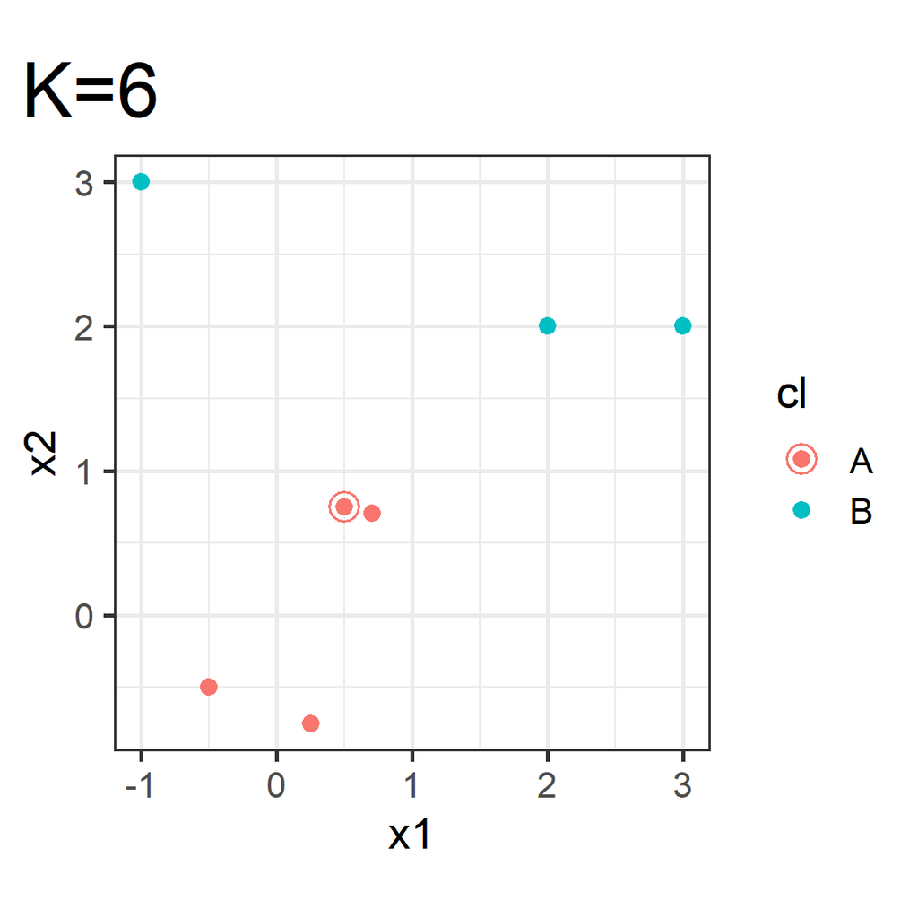

2. Use the image above to identify what would be the class prediction for the circled point under a kNN model with `K = 6` and `weight_func = "inv"`
3. Explain if and why it important to standardise your data when conducting kNN
4. Identify one limitation of a kNN model for probabilistic classification

#### 2. kNN practice

We have previously been fitting kNN to a subset of the penguins data that only contained two classes. Lets fit a full version of kNN to the full penguins data!

1. Use cross-validation on the training data to select the number of neighbours $K$, the distance parameter $p$ and whether to use inverse distance weighting for the penguins data. Think carefully about what criteria to use for your cross-validation
2. Refit the best model that you found in cross-validation and evaluate its test set performance

#### 3. Logistic regression theory

1. Sketch the logistic function
2. Explain the role of the logistic function in logistic regression
3. Use the logistic function to derive that fact the logistic regression models the log-odds as being linear in features $x$
4. Explain if and why it important to standardise your data when conducting logistic regression
5. Explain one advantage and one disadvantage of logistic regression when compared to kNN

#### 4. Logistic regression practice

This problem uses logistic regression on the penguins data.

1. Fit a multi-class logistic regression model to the training data. You may want to look at the [multinom_reg](https://parsnip.tidymodels.org/reference/multinom_reg.html) tidymodels page to get started.
2. Compute the confusion matrices for training and test sets, and thus the error for the test set (classifying based on which class has the highest predicted probability).

*Note, that unlike in kNN, logistic regression can actually makes in-sample predictions and it can be useful to compare in and out of sample performance*

3. Check the logistic regression model fit. First plot the data-in-the-model-space. Separate the observations by their true class label and produce box-plots of the model probabilities assigned to being in the correct class. Do this for both the training and testing observations. You can use this code to make the predictions.

```r
p_tr_pred_prob <- multi_logistic_fit |>
  augment(new_data = p_tr, type.predict="prob") |>
  mutate(.pred_correct = as.numeric(species == "Adelie")*.pred_Adelie + as.numeric(species == "Chinstrap")*.pred_Chinstrap + as.numeric(species == "Gentoo")*.pred_Gentoo) |>
  mutate(.pred_predicted = as.numeric(.pred_class == "Adelie")*.pred_Adelie + as.numeric(.pred_class == "Chinstrap")*.pred_Chinstrap + as.numeric(.pred_class == "Gentoo")*.pred_Gentoo)

p_ts_pred_prob <- multi_logistic_fit |>
  augment(new_data = p_ts, type.predict="prob") |>
  mutate(.pred_correct = as.numeric(species == "Adelie")*.pred_Adelie + as.numeric(species == "Chinstrap")*.pred_Chinstrap + as.numeric(species == "Gentoo")*.pred_Gentoo) |>
  mutate(.pred_predicted = as.numeric(.pred_class == "Adelie")*.pred_Adelie + as.numeric(.pred_class == "Chinstrap")*.pred_Chinstrap + as.numeric(.pred_class == "Gentoo")*.pred_Gentoo)
```

Then examine the model-in-the-data-space. Use a tour, colouring the observations according to which class is believed to be most likely and making the shape of the point whether they were correctly or incorrectly classified that way.

#### 5. Interactively explore misclassifications

Here you are going to use interactive graphics to explore the misclassifications from your kNN (or logistic regression). We’ll need to use detourr to accomplish this. The code below makes a scatterplot of the confusion matrix, where points corresponding to a class have been spread apart by jittering. This plot is linked to a tour plot. Try:

1. Selecting penguins that have been misclassified, from the display of the confusion matrix. Observe where they are in the data space. Are they in an area where it is hard to distinguish the groups?
2. Selecting neighbouring points in the tour, and examine where they are in the confusion matrix.

```r
p_cl <- p_tidy_std |>
  mutate(pspecies = predict(knn_final_fit$fit, p_tidy_std)) |>
  dplyr::select(bl:bm, species, pspecies) |>
  mutate(sp_jit = jitter(as.numeric(species)),
         psp_jit = jitter(as.numeric(pspecies)))
p_cl_shared <- SharedData$new(p_cl)

detour_plot <- detour(p_cl_shared, tour_aes(
  projection = bl:bm,
  colour = species)) |>
    tour_path(grand_tour(2),
                    max_bases=50, fps = 60) |>
       show_scatter(alpha = 0.9, axes = FALSE,
                    width = "100%", height = "450px")

conf_mat <- plot_ly(p_cl_shared,
                    x = ~psp_jit,
                    y = ~sp_jit,
                    color = ~species,
                    colors = viridis_pal(option = "D")(3),
                    height = 450) |>
  highlight(on = "plotly_selected",
              off = "plotly_doubleclick") %>%
    add_trace(type = "scatter",
              mode = "markers")

bscols(
     detour_plot, conf_mat,
     widths = c(5, 6)
 )
```

## 👋 Finishing up

Make sure you say thanks and good-bye to your tutor. This is a time to also report what you enjoyed and what you found difficult.